# 20260109 PPX1,PPN1 reentry: early growth rate instead of lag time

Kushal Raj Roy

2026-11-19, updated 2026-11-19

```r
require(tidyverse)
library(gcplyr)
old <- theme_set(theme_bw(base_size = 14))
```

## Why this notebook

In `20260109_PPX1_PPN1_reentry.Rmd`, `gcplyr::lag_time()` gives noisy, mostly meaningless lag times. In 52 of 56 wells it warns “lag time is less than min(x), indicating no identifiable lag phase”: the maximum per-capita growth rate falls at 0.49 h, the first timepoint where a 5-point derivative exists, so the reported lag (~0.12 h) is earlier than the first read. The cells grow from the first reads.

Swapping the single blank for row-matched blanks did not change lag-time spread (median within-group SD 0.0048 vs 0.0047 h), so the blank is not what makes the lag noisy.

This notebook reports two measures that do not need a lag phase to exist and are not set by inoculum density:

1. **Early growth rate**: slope of log(OD - blank) vs time over the first `EARLY_WINDOW` hours (per hour).
2. **Time to double starting density**: first time the smoothed, blank-subtracted OD reaches 2x its starting value (median of the first 3 reads).

Starting OD sits only 0.02 to 0.1 above the blank, so both are computed under the lowest, median and highest empty-well blank to show how much the blank choice matters.

## Parameters

```r
EARLY_WINDOW <- 3      # hours used for the early growth-rate fit
EMPTY_MAX_OD <- 0.12   # a well whose max OD stays below this is treated as empty
```

## Data

```r
dat_wide <- read_wides(files = "../input/20260109_PPX1_PPN1_reentry.csv") |>
  mutate(Time = time_length(hms(Time), unit = "hour"))
dat_tidy <- trans_wide_to_tidy(dat_wide, id_cols = c("file", "Time")) |>
  mutate(Col = as.integer(substring(Well, 2)))
meta_info <- read_csv("../input/20260109_plate_layout.csv", show_col_types = FALSE) |>
  mutate(Starved_h = as.numeric(sub("h", "", Group)))
```

## Blank

Column 6 wells drift upward by about 0.015 OD over the run (contamination or evaporation), so they are excluded from the blank.

```r
well_stats <- dat_tidy |>
  group_by(Well, Col) |>
  summarize(max_od = max(Measurements), med_od = median(Measurements),
            drift = max(Measurements) - min(Measurements), .groups = "drop")
well_stats |> filter(Col == 6) |> select(Well, drift)
```

| Well | drift |
| --- | --- |
| A6 | 0.001 |
| B6 | 0.015 |
| C6 | 0.016 |
| D6 | 0.018 |
| E6 | 0.019 |
| F6 | 0.017 |
| G6 | 0.011 |
| H6 | 0.003 |

```r
blank_wells <- well_stats |> filter(max_od < EMPTY_MAX_OD, Col != 6)
blanks <- c(low  = min(blank_wells$med_od),
            mid  = median(blank_wells$med_od),
            high = max(blank_wells$med_od))
round(blanks, 4)
```

```
  low   mid  high
0.083 0.089 0.103
```

## Early growth metrics

```r
early_metrics <- function(blank_value) {
  dat_tidy |>
    filter(Well %in% meta_info$Well) |>
    arrange(Well, Time) |>
    group_by(Well) |>
    mutate(y = Measurements - blank_value,
           y_sm = smooth_data(x = Time, y = y, sm_method = "loess",
                              span = .15, degree = 1)) |>
    summarize(
      y0 = median(y[1:3]),
      t_double = first_above(x = Time, y = y_sm, threshold = 2 * y0, return = "x"),
      r_early = {
        k <- Time <= EARLY_WINDOW & y > 0
        unname(coef(lm(log(y[k]) ~ Time[k]))[2])
      },
      .groups = "drop")
}

res <- imap_dfr(blanks, \(b, nm) early_metrics(b) |> mutate(blank = nm)) |>
  left_join(meta_info, by = "Well")

grp <- res |>
  group_by(blank, Genotype, Starved_h) |>
  summarize(n = n(), y0 = mean(y0),
            t_double_mean = mean(t_double), t_double_sd = sd(t_double),
            r_mean = mean(r_early), r_sd = sd(r_early), .groups = "drop")
grp |> filter(blank == "mid") |> select(-blank)
```

| Genotype | Starved_h | n | y0 | t_double_mean | t_double_sd | r_mean | r_sd |
| --- | --- | --- | --- | --- | --- | --- | --- |
| PPX1,PPN1 KO | 0.0 | 4 | 0.03675 | 2.208930 | 0.64298805 | 0.3360308 | 0.079356606 |
| PPX1,PPN1 KO | 0.5 | 4 | 0.09800 | 2.396028 | 0.42620989 | 0.2995441 | 0.046768160 |
| PPX1,PPN1 KO | 1.0 | 4 | 0.07675 | 2.127751 | 0.33220408 | 0.3503249 | 0.044157987 |
| PPX1,PPN1 KO | 2.0 | 4 | 0.06400 | 2.247394 | 0.33771332 | 0.3441838 | 0.039766778 |
| PPX1,PPN1 KO | 3.0 | 4 | 0.10000 | 2.218386 | 0.77908131 | 0.3425339 | 0.078355340 |
| PPX1,PPN1 KO | 4.0 | 4 | 0.05100 | 2.153344 | 0.26208343 | 0.3500833 | 0.033599215 |
| PPX1,PPN1 KO | 6.0 | 4 | 0.07500 | 2.635622 | 0.08016217 | 0.2889892 | 0.007962981 |
| Wildtype | 0.0 | 4 | 0.02725 | 2.260708 | 0.28196698 | 0.3427040 | 0.044439244 |
| Wildtype | 0.5 | 4 | 0.03825 | 1.961363 | 0.24187666 | 0.3970793 | 0.033439867 |
| Wildtype | 1.0 | 4 | 0.04300 | 1.891035 | 0.21819398 | 0.4145788 | 0.033883887 |

[output cut: 4 more lines]

Blank sensitivity of the group means:

```r
grp |>
  select(blank, Genotype, Starved_h, r_mean, t_double_mean) |>
  pivot_wider(names_from = blank, values_from = c(r_mean, t_double_mean))
```

| Genotype | Starved_h | r_mean_high | r_mean_low | r_mean_mid | t_double_mean_high | t_double_mean_low | t_double_mean_mid |
| --- | --- | --- | --- | --- | --- | --- | --- |
| PPX1,PPN1 KO | 0.0 | 0.4530451 | 0.3035522 | 0.3360308 | 1.549046 | 2.463825 | 2.208930 |
| PPX1,PPN1 KO | 0.5 | 0.3321262 | 0.2875638 | 0.2995441 | 2.119995 | 2.510932 | 2.396028 |
| PPX1,PPN1 KO | 1.0 | 0.3975165 | 0.3335547 | 0.3503249 | 1.833941 | 2.247435 | 2.127751 |
| PPX1,PPN1 KO | 2.0 | 0.4036773 | 0.3240154 | 0.3441838 | 1.878932 | 2.394151 | 2.247394 |
| PPX1,PPN1 KO | 3.0 | 0.3787942 | 0.3291672 | 0.3425339 | 1.986138 | 2.319409 | 2.218386 |
| PPX1,PPN1 KO | 4.0 | 0.4287799 | 0.3250076 | 0.3500833 | 1.682144 | 2.339737 | 2.153344 |
| PPX1,PPN1 KO | 6.0 | 0.3335980 | 0.2734667 | 0.2889892 | 2.242275 | 2.789954 | 2.635622 |
| Wildtype | 0.0 | 0.5250890 | 0.2999819 | 0.3427040 | 1.449602 | 2.524292 | 2.260708 |
| Wildtype | 0.5 | 0.5202014 | 0.3616279 | 0.3970793 | 1.432907 | 2.153768 | 1.961363 |
| Wildtype | 1.0 | 0.5239993 | 0.3814943 | 0.4145788 | 1.444556 | 2.061545 | 1.891035 |

[output cut: 4 more lines]

## Figure

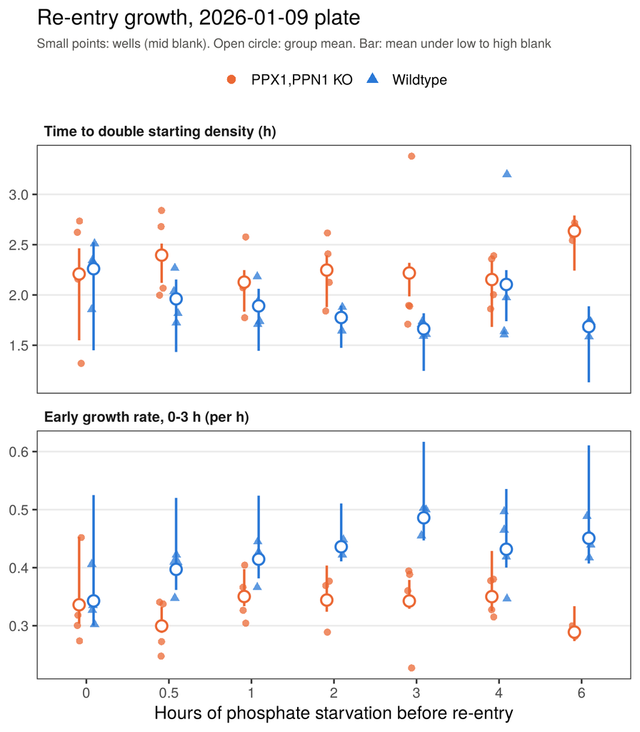

```r
geno_cols <- c("Wildtype" = "#2a78d6", "PPX1,PPN1 KO" = "#eb6834")
long <- res |>
  select(Well, Genotype, Starved_h, blank, t_double, r_early) |>
  pivot_longer(c(t_double, r_early), names_to = "metric") |>
  mutate(metric = factor(metric, c("t_double", "r_early"),
                         c("Time to double starting density (h)",
                           paste0("Early growth rate, 0-", EARLY_WINDOW, " h (per h)"))))
pts <- filter(long, blank == "mid")
rng <- long |>
  group_by(Genotype, Starved_h, metric, blank) |>
  summarize(m = mean(value), .groups = "drop") |>
  group_by(Genotype, Starved_h, metric) |>
  summarize(lo = min(m), hi = max(m), mid = m[blank == "mid"], .groups = "drop")
dodge <- position_dodge(width = 0.35)

p <- ggplot(pts, aes(x = factor(Starved_h), y = value, colour = Genotype, shape = Genotype)) +
  geom_point(position = position_jitterdodge(jitter.width = 0.12, dodge.width = 0.35),
             size = 2.2, alpha = 0.75) +
  geom_linerange(data = rng, aes(y = mid, ymin = lo, ymax = hi),
                 position = dodge, linewidth = 0.9) +
  geom_point(data = rng, aes(y = mid), position = dodge,
             size = 3.4, shape = 21, fill = "white", stroke = 1.2) +
  facet_wrap(~metric, ncol = 1, scales = "free_y") +
  scale_colour_manual(values = geno_cols) +
  scale_shape_manual(values = c(16, 17)) +
  guides(colour = guide_legend(override.aes = list(shape = c(16, 17), linetype = 0,
                                                   size = 3, fill = NA, stroke = 0.5)),
         shape = "none") +
  labs(x = "Hours of phosphate starvation before re-entry", y = NULL,
       colour = NULL, shape = NULL,
       title = "Re-entry growth, 2026-01-09 plate",
       subtitle = "Small points: wells (mid blank). Open circle: group mean. Bar: mean under low to high blank") +
  theme(legend.position = "top", panel.grid.minor = element_blank(),
        panel.grid.major.x = element_blank(), strip.background = element_blank(),
        strip.text = element_text(hjust = 0, face = "bold"),
        plot.subtitle = element_text(size = 10, colour = "#52514e"))
p
```

```r
ggsave("../output/20260109_early_growth_rate.png", p, width = 7, height = 8, dpi = 200)
write_csv(res, "../output/20260109_early_growth_by_well.csv")
```